# Лабораторная работа №4

Работа с программными пакетами

Перфилов Александр Константинович | Группа НПИбд-03-24

Российский университет дружбы народов, Москва, Россия

27 сентября 2025

# Информация

## Докладчик

- Перфилов Александр Константинович
- Группа НПИбд-03-24
- Российский университет дружбы народов
- https://github.com/AlexanderPErfilovKonstantinivich?tab=repositories

# Вводная часть

## Объект и предмет исследования

- Работа с программными пакетами

## Цель работы

- Получить навыки работы с репозиториями и менеджерами пакетов.

# Ход лабораторной работы

## Заход в режим работы суперпользователя root

- Переходим в пользовательскую учетную запись root с помощью su -

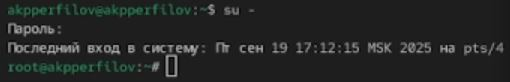

## Переходим в каталог etc/yum.repos.d и изучаем

- Переходим в каталог /etc/yum.repos.d и изучаем информацию о них с помощью ls и cat название_репозитория.repo

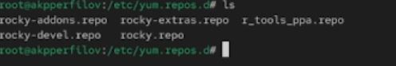

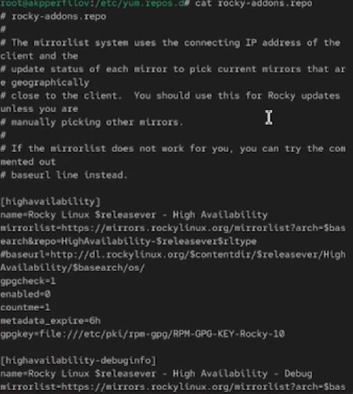

## Выводим на экран список репозиториев

- Выводим списки репозиториев

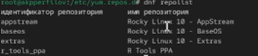

## Ищем в каких пакетах есть слово user

- С помощью команды dnf search user ищем пакеты в которых присутствует слово user

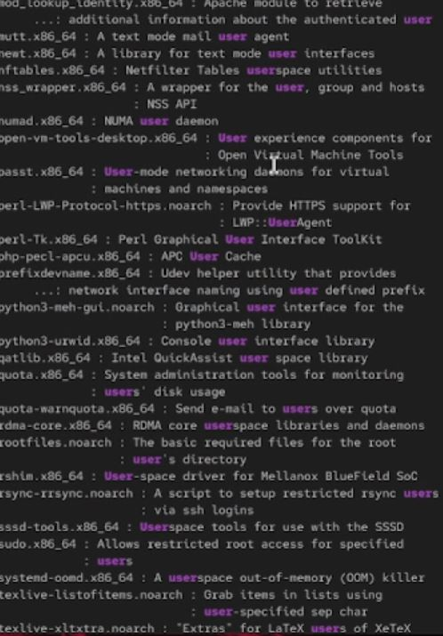

## Устанавливаем nmap

- Проверяем информацию о nmap и устанавливаем nmap

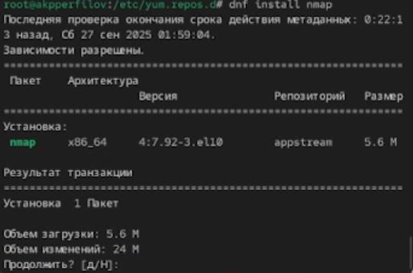

- Устанавливаем nmap*

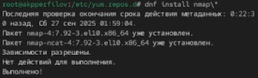

## Удаляем nmap

- Удаляем nmap и nmap*

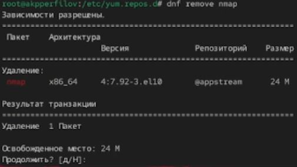

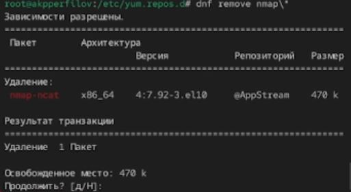

## Устанавливаем группу пакетов RPM Development Tools

- Устанавливаем группу пакетов RPM Development Tools

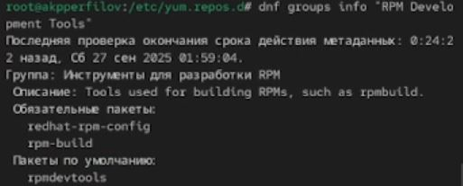

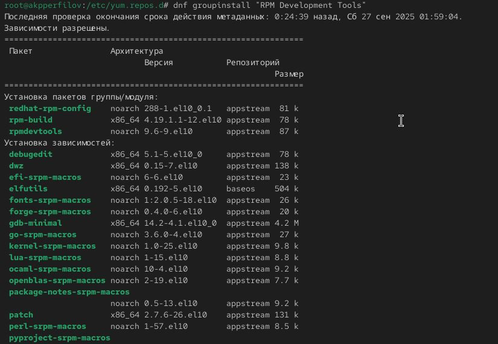

[figure not shown]

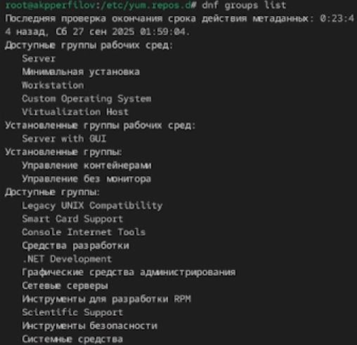

## Удаляем RPM Development Tools

[figure not shown]

## Посмотрим информацию о dnf

- Смотрим информацию где и сколько раз использовался dnf

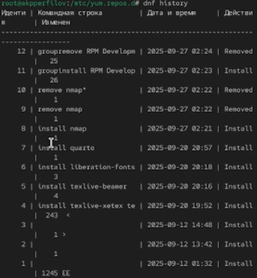

## Отмени последнее действие с dnf

- Отменяем последнее действие с dnf с помощью dnf history undo

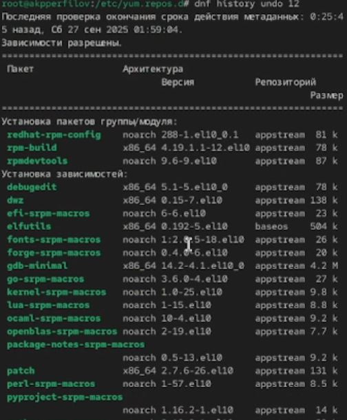

## Устанавливаем текстовый браузер lynx

- Качаем группу rpm lynx

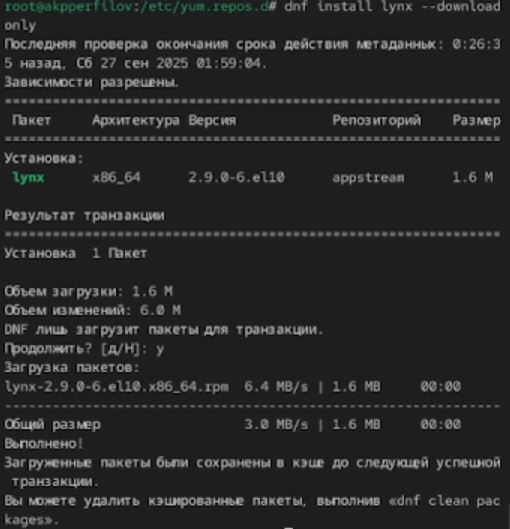

## Ищем в какой каталог был перемещен lynx

- Находим наш пакет в каталогах

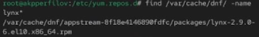

## Переходим в каталог

- Переходим в каталог в котом находится lynx

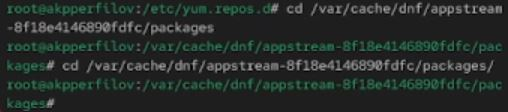

## Устанавливаем rpm пакет

- Устанавливаем rpm пакет в каталоге в ктором находится lynx

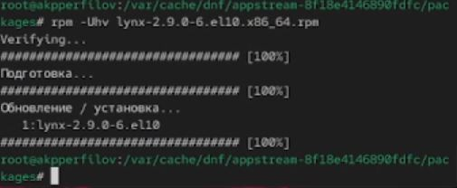

## Находим наш файл

- Определяем расположение файла с помощью команды which lynx

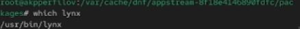

## Определяем к какому пакету принадлежит lynx

- С помощью rpm определяем к какому пакету принадлежит lynx

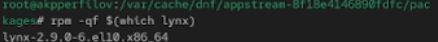

- Получаем дом информацию с помощью rpm -qi lynx

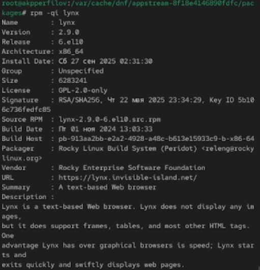

## Список всех файлов

- Получаем список всех файлов в пакете

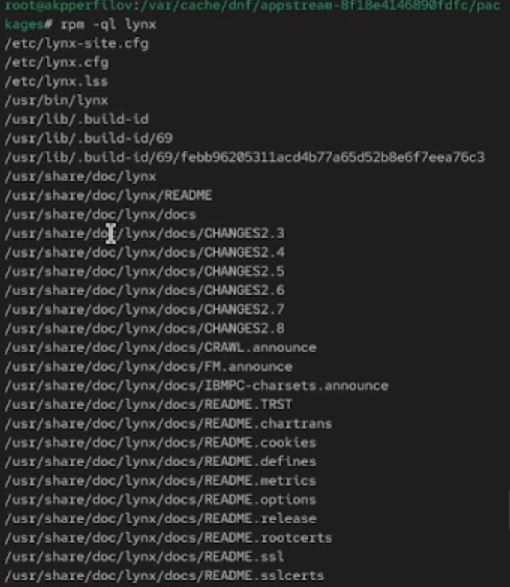

- Получаем перечень файлов с документацией пакета

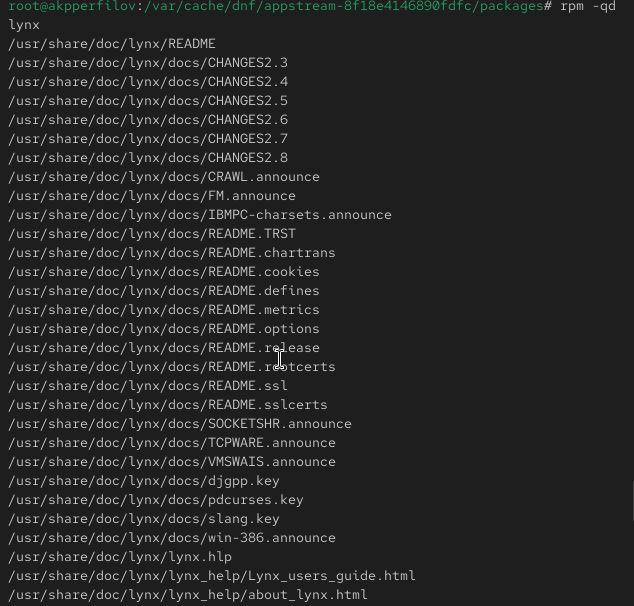

- С помощью команды man lynx смотрим файлы документации

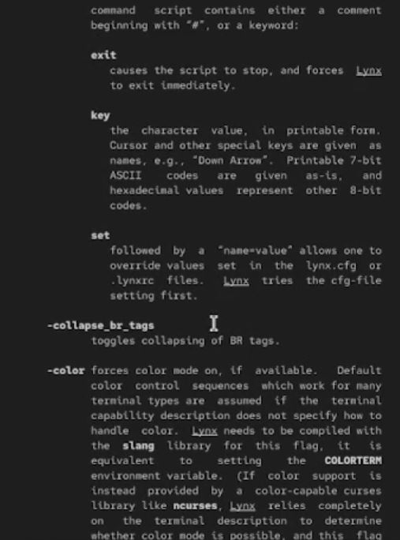

## Конфигурации пакетов

- Выводи на экран перечень и местоположение конфигурационных файлов пакета

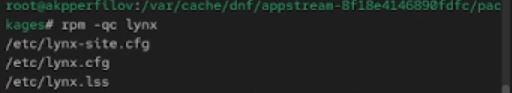

## Расположение скриптов

- Находим расположение и содержание скриптов

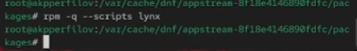

## Переходим в отдельный терминал

- Переходим в отдельный терминал и под своей учетной записью запускаем lynx

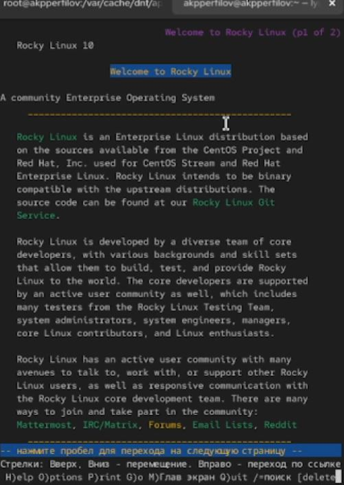